# Starbucks Capstone Challenge

### Introduction

This data set contains simulated data that mimics customer behavior on the Starbucks rewards mobile app. Once every few days, Starbucks sends out an offer to users of the mobile app. An offer can be merely an advertisement for a drink or an actual offer such as a discount or BOGO (buy one get one free). Some users might not receive any offer during certain weeks.

Not all users receive the same offer, and that is the challenge to solve with this data set.

Your task is to combine transaction, demographic and offer data to determine which demographic groups respond best to which offer type. This data set is a simplified version of the real Starbucks app because the underlying simulator only has one product whereas Starbucks actually sells dozens of products.

Every offer has a validity period before the offer expires. As an example, a BOGO offer might be valid for only 5 days. You'll see in the data set that informational offers have a validity period even though these ads are merely providing information about a product; for example, if an informational offer has 7 days of validity, you can assume the customer is feeling the influence of the offer for 7 days after receiving the advertisement.

You'll be given transactional data showing user purchases made on the app including the timestamp of purchase and the amount of money spent on a purchase. This transactional data also has a record for each offer that a user receives as well as a record for when a user actually views the offer. There are also records for when a user completes an offer.

Keep in mind as well that someone using the app might make a purchase through the app without having received an offer or seen an offer.

### Example

To give an example, a user could receive a discount offer buy 10 dollars get 2 off on Monday. The offer is valid for 10 days from receipt. If the customer accumulates at least 10 dollars in purchases during the validity period, the customer completes the offer.

However, there are a few things to watch out for in this data set. Customers do not opt into the offers that they receive; in other words, a user can receive an offer, never actually view the offer, and still complete the offer. For example, a user might receive the "buy 10 dollars get 2 dollars off offer", but the user never opens the offer during the 10 day validity period. The customer spends 15 dollars during those ten days. There will be an offer completion record in the data set; however, the customer was not influenced by the offer because the customer never viewed the offer.

# Query

- Which channel more contributes to customer response?
- Average response time.
- Success-fail distribution by gender.

# Data Sets

The data is contained in three files:

- portfolio.json - containing offer ids and meta data about each offer (duration, type, etc.)
- profile.json - demographic data for each customer
- transcript.json - records for transactions, offers received, offers viewed, and offers completed

```python
import pandas as pd
import numpy as np
import math
import json
import matplotlib.pyplot as plt
from pandas.io.json import json_normalize
import seaborn as sns
from scipy.stats import t
% matplotlib inline
```

```python
# read in the json files
portfolio = pd.read_json('data/portfolio.json', orient='records', lines=True)
profile = pd.read_json('data/profile.json', orient='records', lines=True)
transcript = pd.read_json('data/transcript.json', orient='records', lines=True)
```

```python
def remove_outlier(df, col):
    """
    input: df, and col
    return: removed dataframe
    """
    mean = df[col].mean()
    std = df[col].std()
    q1 = df[col].quantile(0.25)
    q3 = df[col].quantile(0.75)
    IQR = q3 - q1
    removed_outlier = df[(df[col] > q1 - 1.5 * IQR) & (df[col] < q3 + 1.5 * IQR)]
    return removed_outlier
```

## Portfolio Datasets

**portfolio.json**

- id (string) - offer id
- offer_type (string) - type of offer ie BOGO, discount, informational
- difficulty (int) - minimum required spend to complete an offer
- reward (int) - reward given for completing an offer
- duration (int) - time for offer to be open, in days
- channels (list of strings)

```python
### rename id to offer_id to concate the dataset with other datasets
portfolio.rename(columns = {'id': 'offer_id'}, inplace = True)
portfolio.head()
```

|  | channels | difficulty | duration | offer_id | offer_type | reward |
| --- | --- | --- | --- | --- | --- | --- |
| 0 | [email, mobile, social] | 10 | 7 | ae264e3637204a6fb9bb56bc8210ddfd | bogo | 10 |
| 1 | [web, email, mobile, social] | 10 | 5 | 4d5c57ea9a6940dd891ad53e9dbe8da0 | bogo | 10 |
| 2 | [web, email, mobile] | 0 | 4 | 3f207df678b143eea3cee63160fa8bed | informational | 0 |
| 3 | [web, email, mobile] | 5 | 7 | 9b98b8c7a33c4b65b9aebfe6a799e6d9 | bogo | 5 |
| 4 | [web, email] | 20 | 10 | 0b1e1539f2cc45b7b9fa7c272da2e1d7 | discount | 5 |

```python
### check data types
portfolio.info()
```

```
<class 'pandas.core.frame.DataFrame'>
RangeIndex: 10 entries, 0 to 9
Data columns (total 6 columns):
channels      10 non-null object
difficulty    10 non-null int64
duration      10 non-null int64
offer_id      10 non-null object
offer_type    10 non-null object
reward        10 non-null int64
dtypes: int64(3), object(3)
memory usage: 560.0+ bytes
```

```python
### check the number of each offer_type
portfolio.offer_type.value_counts()
```

```
discount         4
bogo             4
informational    2
Name: offer_type, dtype: int64
```

```python
### check the number of nullvalues in datasets
portfolio.isnull().mean()
```

```
channels      0.0
difficulty    0.0
duration      0.0
offer_id      0.0
offer_type    0.0
reward        0.0
dtype: float64
```

## preprocess Datasets

```python
print(portfolio['channels'])
```

```
0         [email, mobile, social]
1    [web, email, mobile, social]
2            [web, email, mobile]
3            [web, email, mobile]
4                    [web, email]
5    [web, email, mobile, social]
6    [web, email, mobile, social]
7         [email, mobile, social]
8    [web, email, mobile, social]
9            [web, email, mobile]
Name: channels, dtype: object
```

```python
### multi-hot-encoding
channels = ["web", "email", "mobile", "social"]
for channel in channels:
    portfolio[channel] = portfolio["channels"].apply(lambda ch: 1 if channel in ch else 0)
portfolio.drop('channels', axis = 1, inplace = True)
```

```python
### all offer types
print(portfolio['offer_type'].unique())
```

```
['bogo' 'informational' 'discount']
```

### show offer type separately

```python
for offer_type in portfolio['offer_type'].unique():
    print(offer_type)
    display(portfolio[portfolio['offer_type'] == offer_type])
```

```
bogo
```

|  | difficulty | duration | offer_id | offer_type | reward | web | email | mobile | social |
| --- | --- | --- | --- | --- | --- | --- | --- | --- | --- |
| 0 | 10 | 7 | ae264e3637204a6fb9bb56bc8210ddfd | bogo | 10 | 0 | 1 | 1 | 1 |
| 1 | 10 | 5 | 4d5c57ea9a6940dd891ad53e9dbe8da0 | bogo | 10 | 1 | 1 | 1 | 1 |
| 3 | 5 | 7 | 9b98b8c7a33c4b65b9aebfe6a799e6d9 | bogo | 5 | 1 | 1 | 1 | 0 |
| 8 | 5 | 5 | f19421c1d4aa40978ebb69ca19b0e20d | bogo | 5 | 1 | 1 | 1 | 1 |

```
informational
```

|  | difficulty | duration | offer_id | offer_type | reward | web | email | mobile | social |
| --- | --- | --- | --- | --- | --- | --- | --- | --- | --- |
| 2 | 0 | 4 | 3f207df678b143eea3cee63160fa8bed | informational | 0 | 1 | 1 | 1 | 0 |
| 7 | 0 | 3 | 5a8bc65990b245e5a138643cd4eb9837 | informational | 0 | 0 | 1 | 1 | 1 |

```
discount
```

|  | difficulty | duration | offer_id | offer_type | reward | web | email | mobile | social |
| --- | --- | --- | --- | --- | --- | --- | --- | --- | --- |
| 4 | 20 | 10 | 0b1e1539f2cc45b7b9fa7c272da2e1d7 | discount | 5 | 1 | 1 | 0 | 0 |
| 5 | 7 | 7 | 2298d6c36e964ae4a3e7e9706d1fb8c2 | discount | 3 | 1 | 1 | 1 | 1 |
| 6 | 10 | 10 | fafdcd668e3743c1bb461111dcafc2a4 | discount | 2 | 1 | 1 | 1 | 1 |
| 9 | 10 | 7 | 2906b810c7d4411798c6938adc9daaa5 | discount | 2 | 1 | 1 | 1 | 0 |

## Profile Datasets

**profile.json**

- age (int) - age of the customer
- became_member_on (int) - date when customer created an app account
- gender (str) - gender of the customer (note some entries contain 'O' for other rather than M or F)
- id (str) - customer id
- income (float) - customer's income

```python
# renaeme 'id' to 'personal_id' to merge it with another datasets
profile.rename(columns = {'id': 'personal_id'}, inplace = True)
profile.head()
```

|  | age | became_member_on | gender | personal_id | income |
| --- | --- | --- | --- | --- | --- |
| 0 | 118 | 20170212 | None | 68be06ca386d4c31939f3a4f0e3dd783 | NaN |
| 1 | 55 | 20170715 | F | 0610b486422d4921ae7d2bf64640c50b | 112000.0 |
| 2 | 118 | 20180712 | None | 38fe809add3b4fcf9315a9694bb96ff5 | NaN |
| 3 | 75 | 20170509 | F | 78afa995795e4d85b5d9ceeca43f5fef | 100000.0 |
| 4 | 118 | 20170804 | None | a03223e636434f42ac4c3df47e8bac43 | NaN |

```python
profile.info()
```

```
<class 'pandas.core.frame.DataFrame'>
RangeIndex: 17000 entries, 0 to 16999
Data columns (total 5 columns):
age                 17000 non-null int64
became_member_on    17000 non-null int64
gender              14825 non-null object
personal_id         17000 non-null object
income              14825 non-null float64
dtypes: float64(1), int64(2), object(2)
memory usage: 664.1+ KB
```

```python
# show percentage of null values in each columun
profile.isnull().mean() * 100
```

```
age                  0.000000
became_member_on     0.000000
gender              12.794118
personal_id          0.000000
income              12.794118
dtype: float64
```

#### the percentage of each gender

```python
profile['gender'].value_counts() / profile['gender'].value_counts().sum() * 100
```

```
M    57.227656
F    41.342327
O     1.430017
Name: gender, dtype: float64
```

[figure not shown]

```python
## visualize the percentage of each gender
plt.figure(figsize = (8,6))
plt.title('frequency of gender')
plt.ylabel('frequency', fontsize = 12)
plt.bar(['Male', 'Female', 'Other'], profile['gender'].value_counts(), color = ['black', 'gray', 'navy'])
plt.show()
```

```python
# show income descriptive statistics
profile[profile['income'].notnull()]['income'].describe()
```

```
count     14825.000000
mean      65404.991568
std       21598.299410
min       30000.000000
25%       49000.000000
50%       64000.000000
75%       80000.000000
max      120000.000000
Name: income, dtype: float64
```

```python
# show income discription
profile.groupby('gender')['income'].describe()
```

| gender | count | mean | std | min | 25% | 50% | 75% | max |
| --- | --- | --- | --- | --- | --- | --- | --- | --- |
| F | 6129.0 | 71306.412139 | 22338.353773 | 30000.0 | 54000.0 | 71000.0 | 88000.0 | 120000.0 |
| M | 8484.0 | 61194.601603 | 20069.517615 | 30000.0 | 45000.0 | 59000.0 | 73000.0 | 120000.0 |
| O | 212.0 | 63287.735849 | 18938.594726 | 30000.0 | 51000.0 | 62000.0 | 79250.0 | 100000.0 |

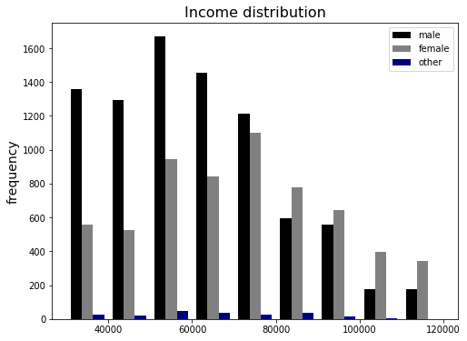

```python
## show income distribution
fig = plt.figure(figsize = (8, 6))
plt.title('Income distribution', fontsize = 16)
income_min, income_max = profile['income'].min(), profile['income'].max()
binsize = np.linspace(income_min, income_max, 10)
male = profile[profile['income'].notnull()].query("gender == 'M'")['income']
female = profile[profile['income'].notnull()].query("gender == 'F'")['income']
other = profile[profile['income'].notnull()].query("gender == 'O'")['income']
plt.hist([male,female,other] ,bins = binsize, color = ['black', 'gray', 'navy'], label = ['male', 'female', 'other'])
plt.ylabel('frequency',fontsize = 14)
plt.legend()
plt.show()
```

According to the graph, female membership incomes seems higher than the others.

```python
# show income represents
profile.groupby("gender").income.describe()
```

| gender | count | mean | std | min | 25% | 50% | 75% | max |
| --- | --- | --- | --- | --- | --- | --- | --- | --- |
| F | 6129.0 | 71306.412139 | 22338.353773 | 30000.0 | 54000.0 | 71000.0 | 88000.0 | 120000.0 |
| M | 8484.0 | 61194.601603 | 20069.517615 | 30000.0 | 45000.0 | 59000.0 | 73000.0 | 120000.0 |
| O | 212.0 | 63287.735849 | 18938.594726 | 30000.0 | 51000.0 | 62000.0 | 79250.0 | 100000.0 |

#### Evaluate start membership year and month

```python
### modity datatyep and make column for month and year of membership
profile['became_member_on'] = pd.to_datetime(profile['became_member_on'], format = '%Y%m%d')
profile['membership_year'] = profile['became_member_on'].dt.year
profile['membership_month'] = profile['became_member_on'].dt.month
```

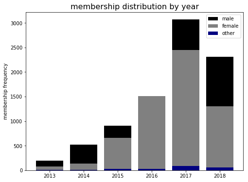

```python
## show membership distribution in each year
male = profile.groupby('gender')['membership_year'].value_counts().sort_index()['M']
female = profile.groupby('gender')['membership_year'].value_counts().sort_index()['F']
other = profile.groupby('gender')['membership_year'].value_counts().sort_index()['O']
plt.figure(figsize = (8, 6))
plt.title("membership distribution by year", fontsize = 16)
plt.bar(np.sort(profile['membership_year'].unique()), male, label = 'male', color = 'black')
plt.bar(np.sort(profile['membership_year'].unique()), female, label ='female', color = 'gray')
plt.bar(np.sort(profile['membership_year'].unique()), other, label = 'other', color = 'navy')
plt.ylabel('membership frequency')
plt.legend()
plt.show()
```

Untill 2017, the number of membership in each year increases

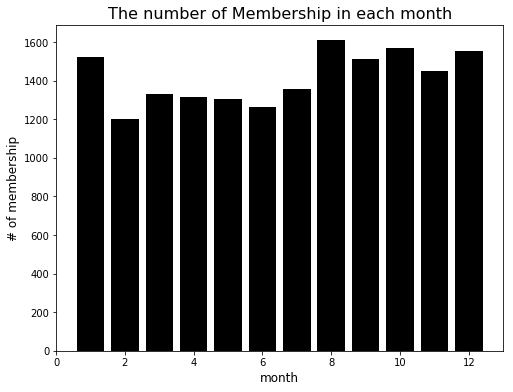

```python
# show membership in each month
plt.figure(figsize = (8, 6))
plt.title('The number of Membership in each month', fontsize = 16)
plt.bar(np.sort(profile['membership_month'].unique()), profile['membership_month'].value_counts().sort_index(), color = 'black')
plt.xlabel('month', fontsize = 12)
plt.ylabel('# of membership', fontsize = 12)
plt.show()
```

```python
profile.membership_month.describe()
```

```
count    17000.000000
mean         6.683529
std          3.487098
min          1.000000
25%          4.000000
50%          7.000000
75%         10.000000
max         12.000000
Name: membership_month, dtype: float64
```

```python
# show profile
profile.head(5)
```

|  | age | became_member_on | gender | personal_id | income | membership_year | membership_month |
| --- | --- | --- | --- | --- | --- | --- | --- |
| 0 | 118 | 2017-02-12 | None | 68be06ca386d4c31939f3a4f0e3dd783 | NaN | 2017 | 2 |
| 1 | 55 | 2017-07-15 | F | 0610b486422d4921ae7d2bf64640c50b | 112000.0 | 2017 | 7 |
| 2 | 118 | 2018-07-12 | None | 38fe809add3b4fcf9315a9694bb96ff5 | NaN | 2018 | 7 |
| 3 | 75 | 2017-05-09 | F | 78afa995795e4d85b5d9ceeca43f5fef | 100000.0 | 2017 | 5 |
| 4 | 118 | 2017-08-04 | None | a03223e636434f42ac4c3df47e8bac43 | NaN | 2017 | 8 |

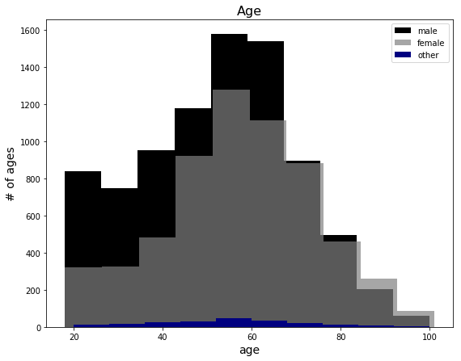

```python
# show age distribution
plt.figure(figsize = (9, 7))
plt.hist(profile.query('gender == "M"').age, label = 'male', color = 'black')
plt.hist(profile.query('gender == "F"').age, label = 'female', color ='gray', alpha = 0.7)
plt.hist(profile.query('gender == "O"').age, label ='other', color = 'navy')
plt.title('Age', fontsize = 16)
plt.ylabel('# of ages', fontsize= 14)
plt.xlabel('age', fontsize = 14)
plt.legend()
plt.show()
```

# show default gender and age

```python
### After removing outliers
removed_outlier_age = remove_outlier(profile, 'age')
removed_outlier_age['age'].describe()
```

```
count    14825.000000
mean        54.393524
std         17.383705
min         18.000000
25%         42.000000
50%         55.000000
75%         66.000000
max        101.000000
Name: age, dtype: float64
```

## Transcript Datasets

----- effective offers -------

- offer received --> offer viewed --> transaction --> offer completed (BOGB/discount offers)
- offer received --> offer viewed --> transaction (information offers)

----- ineffective offers -----

- offer received --> offer viewed !--> transaction

----- offers are received but no action taken -----

- offer received !-->

**transcript.json**

- event (str) - record description (ie transaction, offer received, offer viewed, etc.)
- person (str) - customer id
- time (int) - time in hours since start of test. The data begins at time t=0
- value - (dict of strings) - either an offer id or transaction amount depending on the record

```python
# convert 'person' to 'personal_id' to merge with another datasets
transcript.rename(columns = {'person': 'personal_id'}, inplace = True)
transcript.head()
```

|  | event | personal_id | time | value |
| --- | --- | --- | --- | --- |
| 0 | offer received | 78afa995795e4d85b5d9ceeca43f5fef | 0 | {'offer id': '9b98b8c7a33c4b65b9aebfe6a799e6d9'} |
| 1 | offer received | a03223e636434f42ac4c3df47e8bac43 | 0 | {'offer id': '0b1e1539f2cc45b7b9fa7c272da2e1d7'} |
| 2 | offer received | e2127556f4f64592b11af22de27a7932 | 0 | {'offer id': '2906b810c7d4411798c6938adc9daaa5'} |
| 3 | offer received | 8ec6ce2a7e7949b1bf142def7d0e0586 | 0 | {'offer id': 'fafdcd668e3743c1bb461111dcafc2a4'} |
| 4 | offer received | 68617ca6246f4fbc85e91a2a49552598 | 0 | {'offer id': '4d5c57ea9a6940dd891ad53e9dbe8da0'} |

```python
transcript.info()
```

```
<class 'pandas.core.frame.DataFrame'>
RangeIndex: 306534 entries, 0 to 306533
Data columns (total 4 columns):
event          306534 non-null object
personal_id    306534 non-null object
time           306534 non-null int64
value          306534 non-null object
dtypes: int64(1), object(3)
memory usage: 9.4+ MB
```

```python
# the mean of null values
transcript.isna().mean()
```

```
event          0.0
personal_id    0.0
time           0.0
value          0.0
dtype: float64
```

```python
# show unique events
print(transcript['event'].unique())
```

```
['offer received' 'offer viewed' 'transaction' 'offer completed']
```

```python
# show event counts
transcript['event'].value_counts()
```

```
transaction        138953
offer received      76277
offer viewed        57725
offer completed     33579
Name: event, dtype: int64
```

```python
# show proportions of transaction and the other events
transaction_ = transcript[transcript['event'] == 'transaction']['event'].value_counts().sum() / transcript['event'].shape[0] * 100
print("% of transaction: ", int(transaction_), '%')
offer_ = transcript[transcript['event'] != 'transaction']['event'].value_counts().sum() / transcript['event'].shape[0] * 100
print("% of offer_event: ", int(offer_), '%')
```

```
% of transaction:  45 %
% of offer_event:  54 %
```

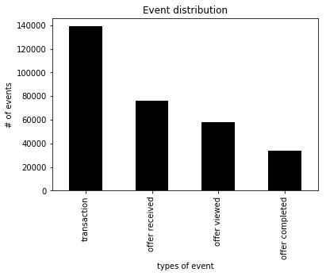

```python
# show event distribution
transcript['event'].value_counts().plot('bar', color = 'black')
plt.title('Event distribution')
plt.xlabel('types of event')
plt.ylabel('# of events')
plt.show()
```

```python
# separate value column which includes offer__id and amount
id_amount_reward = json_normalize(transcript['value'])
id_amount_reward['offer_id'] = np.where(id_amount_reward['offer_id'].notnull(), id_amount_reward['offer_id'], id_amount_reward['offer id'])
id_amount_reward.drop('offer id', axis = 1, inplace = True)
transcript = pd.concat([transcript, id_amount_reward], axis = 1)
transcript.drop('value', axis = 1, inplace = True)
```

```python
# show reselts
transcript.head()
```

|  | event | personal_id | time | amount | offer_id | reward |
| --- | --- | --- | --- | --- | --- | --- |
| 0 | offer received | 78afa995795e4d85b5d9ceeca43f5fef | 0 | NaN | 9b98b8c7a33c4b65b9aebfe6a799e6d9 | NaN |
| 1 | offer received | a03223e636434f42ac4c3df47e8bac43 | 0 | NaN | 0b1e1539f2cc45b7b9fa7c272da2e1d7 | NaN |
| 2 | offer received | e2127556f4f64592b11af22de27a7932 | 0 | NaN | 2906b810c7d4411798c6938adc9daaa5 | NaN |
| 3 | offer received | 8ec6ce2a7e7949b1bf142def7d0e0586 | 0 | NaN | fafdcd668e3743c1bb461111dcafc2a4 | NaN |
| 4 | offer received | 68617ca6246f4fbc85e91a2a49552598 | 0 | NaN | 4d5c57ea9a6940dd891ad53e9dbe8da0 | NaN |

```python
# check if amount is completely associated with transaction and
# reward is assiciated with offer_complted

print('the number of event: ', len(transcript['event']))
print('the number of transaction: ', len(transcript[transcript['event'] == 'transaction']))
print('the number of amount: ', transcript['amount'].notna().sum())
print('the number of offer completed: ', len(transcript[transcript['event'] == 'offer completed']))
print('the number of reward: ', transcript['reward'].notna().sum())
```

```
the number of event:  306534
the number of transaction:  138953
the number of amount:  138953
the number of offer completed:  33579
the number of reward:  33579
```

amount: (numeric) money spent in "transaction" The number of 'amount' is associated with # of 'transaction' --> 138953 / 306534

reward: (numeric) money gained from "offer completed"

The number of 'reward' is associated with # of 'offer completed' --> 33579 / 306534

```python
print("the number of personal_ids: ", len(transcript['personal_id']))
print("the number of unique personal_ids: ", transcript['personal_id'].nunique())
```

```
the number of personal_ids:  306534
the number of unique personal_ids:  17000
```

Hence, The same members were offered multiple times

## separate each event types

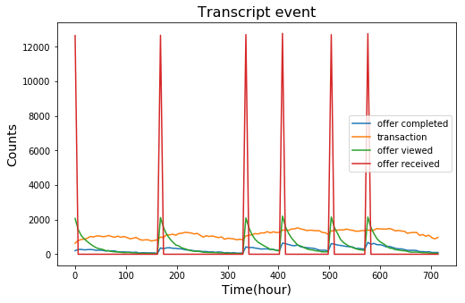

```python
## show event by. time series after the test starts
from collections import defaultdict
df = transcript.merge(portfolio.drop('reward', axis = 1), on = 'offer_id', how = 'outer')
received_time = transcript[transcript['event'] == 'offer received']['time']
time_series = defaultdict(int)

for t in df['time'].unique():
    time_series[t] = 0
for t in received_time:
    time_series[t] += 1
received_time = pd.Series(time_series)


### plot time series
plt.figure(figsize = (8, 5))
labels = ['offer completed', 'transaction', 'offer viewed', 'offer received']
for label in labels:
    if label != 'offer received':
        df.groupby('event')['time'].value_counts().sort_index()[label].plot()
    if label == 'offer received':
        received_time.plot()
plt.title('Transcript event', fontsize = 16)
plt.ylabel('Counts', fontsize = 14)
plt.xlabel('Time(hour)', fontsize = 14)
plt.legend(labels)
plt.show()
```

### offer received

```python
offer_received = transcript.query("event == 'offer received'")
print('the number of offer received: ', offer_received.shape[0])
offer_received.head()
```

```
the number of offer received:  76277
```

|  | event | personal_id | time | amount | offer_id | reward |
| --- | --- | --- | --- | --- | --- | --- |
| 0 | offer received | 78afa995795e4d85b5d9ceeca43f5fef | 0 | NaN | 9b98b8c7a33c4b65b9aebfe6a799e6d9 | NaN |
| 1 | offer received | a03223e636434f42ac4c3df47e8bac43 | 0 | NaN | 0b1e1539f2cc45b7b9fa7c272da2e1d7 | NaN |
| 2 | offer received | e2127556f4f64592b11af22de27a7932 | 0 | NaN | 2906b810c7d4411798c6938adc9daaa5 | NaN |
| 3 | offer received | 8ec6ce2a7e7949b1bf142def7d0e0586 | 0 | NaN | fafdcd668e3743c1bb461111dcafc2a4 | NaN |
| 4 | offer received | 68617ca6246f4fbc85e91a2a49552598 | 0 | NaN | 4d5c57ea9a6940dd891ad53e9dbe8da0 | NaN |

```python
print('the number of offer received: ', offer_received.shape[0])
print("the number of offer received at time 0: ", offer_received[offer_received['time'] == 0].shape[0])
print("The number of less than the first quantile of time is: ",offer_received[offer_received['time'] <= offer_received['time'].quantile(0.25)].shape[0])
print("The number of less than the second quantile of time is: ",offer_received[offer_received['time'] <= offer_received['time'].quantile(0.50)].shape[0])
print("The number of less than the third quantile of time is: ",offer_received[offer_received['time'] <= offer_received['time'].quantile(0.75)].shape[0])
```

```
the number of offer received:  76277
the number of offer received at time 0:  12650
The number of less than the first quantile of time is:  25319
The number of less than the second quantile of time is:  50808
The number of less than the third quantile of time is:  63512
```

### offer viewed

```python
offer_viewed = transcript.query("event == 'offer viewed'")
offer_viewed.head()
```

|  | event | personal_id | time | amount | offer_id | reward |
| --- | --- | --- | --- | --- | --- | --- |
| 12650 | offer viewed | 389bc3fa690240e798340f5a15918d5c | 0 | NaN | f19421c1d4aa40978ebb69ca19b0e20d | NaN |
| 12651 | offer viewed | d1ede868e29245ea91818a903fec04c6 | 0 | NaN | 5a8bc65990b245e5a138643cd4eb9837 | NaN |
| 12652 | offer viewed | 102e9454054946fda62242d2e176fdce | 0 | NaN | 4d5c57ea9a6940dd891ad53e9dbe8da0 | NaN |
| 12653 | offer viewed | 02c083884c7d45b39cc68e1314fec56c | 0 | NaN | ae264e3637204a6fb9bb56bc8210ddfd | NaN |
| 12655 | offer viewed | be8a5d1981a2458d90b255ddc7e0d174 | 0 | NaN | 5a8bc65990b245e5a138643cd4eb9837 | NaN |

```python
print('the number of offer viewed: ', offer_viewed.shape[0])
print("the number of time 0: ", offer_viewed[offer_viewed['time'] == 0].shape[0])
print("The number of less than the first quantile of time is: ",offer_viewed[offer_viewed['time'] <= offer_viewed['time'].quantile(0.25)].shape[0])
print("The number of less than the second quantile of time is: ",offer_viewed[offer_viewed['time'] <= offer_viewed['time'].quantile(0.50)].shape[0])
print("The number of less than the third quantile of time is: ",offer_viewed[offer_viewed['time'] <= offer_viewed['time'].quantile(0.75)].shape[0])
```

```
the number of offer viewed:  57725
the number of time 0:  2072
The number of less than the first quantile of time is:  14762
The number of less than the second quantile of time is:  31020
The number of less than the third quantile of time is:  43405
```

### transaction

```python
transaction = transcript.query("event == 'transaction'")
transaction.head()
```

|  | event | personal_id | time | amount | offer_id | reward |
| --- | --- | --- | --- | --- | --- | --- |
| 12654 | transaction | 02c083884c7d45b39cc68e1314fec56c | 0 | 0.83 | NaN | NaN |
| 12657 | transaction | 9fa9ae8f57894cc9a3b8a9bbe0fc1b2f | 0 | 34.56 | NaN | NaN |
| 12659 | transaction | 54890f68699049c2a04d415abc25e717 | 0 | 13.23 | NaN | NaN |
| 12670 | transaction | b2f1cd155b864803ad8334cdf13c4bd2 | 0 | 19.51 | NaN | NaN |
| 12671 | transaction | fe97aa22dd3e48c8b143116a8403dd52 | 0 | 18.97 | NaN | NaN |

```python
print('the number of offer transaction: ', transaction.shape[0])
print("the number of time 0: ", transaction[transaction['time'] == 0].shape[0])
print("The number of less than the first quantile of time is: ",transaction[transaction['time'] <= transaction['time'].quantile(0.25)].shape[0])
print("The number of less than the second quantile of time is: ",transaction[transaction['time'] <= transaction['time'].quantile(0.50)].shape[0])
print("The number of less than the third quantile of time is: ",transaction[transaction['time'] <= transaction['time'].quantile(0.75)].shape[0])
```

```
the number of offer transaction:  138953
the number of time 0:  633
The number of less than the first quantile of time is:  34805
The number of less than the second quantile of time is:  69776
The number of less than the third quantile of time is:  104348
```

### offer completed

```python
offer_completed = transcript.query("event == 'offer completed'")
offer_completed.head()
```

|  | event | personal_id | time | amount | offer_id | reward |
| --- | --- | --- | --- | --- | --- | --- |
| 12658 | offer completed | 9fa9ae8f57894cc9a3b8a9bbe0fc1b2f | 0 | NaN | 2906b810c7d4411798c6938adc9daaa5 | 2.0 |
| 12672 | offer completed | fe97aa22dd3e48c8b143116a8403dd52 | 0 | NaN | fafdcd668e3743c1bb461111dcafc2a4 | 2.0 |
| 12679 | offer completed | 629fc02d56414d91bca360decdfa9288 | 0 | NaN | 9b98b8c7a33c4b65b9aebfe6a799e6d9 | 5.0 |
| 12692 | offer completed | 676506bad68e4161b9bbaffeb039626b | 0 | NaN | ae264e3637204a6fb9bb56bc8210ddfd | 10.0 |
| 12697 | offer completed | 8f7dd3b2afe14c078eb4f6e6fe4ba97d | 0 | NaN | 4d5c57ea9a6940dd891ad53e9dbe8da0 | 10.0 |

```python
print('the number of offer completed: ', offer_completed.shape[0])
print("the number of time 0: ", offer_completed[offer_completed['time'] == 0].shape[0])
print("The number of less than the first quantile of time is: ",offer_completed[offer_completed['time'] <= offer_completed['time'].quantile(0.25)].shape[0])
print("The number of less than the second quantile of time is: ",offer_completed[offer_completed['time'] <= offer_completed['time'].quantile(0.50)].shape[0])
print("The number of less than the third quantile of time is: ",offer_completed[offer_completed['time'] <= offer_completed['time'].quantile(0.75)].shape[0])
```

```
the number of offer completed:  33579
the number of time 0:  206
The number of less than the first quantile of time is:  8521
The number of less than the second quantile of time is:  16801
The number of less than the third quantile of time is:  25474
```

# Explore and Clean datasets

```python
offer_received.head()
```

|  | event | personal_id | time | amount | offer_id | reward |
| --- | --- | --- | --- | --- | --- | --- |
| 0 | offer received | 78afa995795e4d85b5d9ceeca43f5fef | 0 | NaN | 9b98b8c7a33c4b65b9aebfe6a799e6d9 | NaN |
| 1 | offer received | a03223e636434f42ac4c3df47e8bac43 | 0 | NaN | 0b1e1539f2cc45b7b9fa7c272da2e1d7 | NaN |
| 2 | offer received | e2127556f4f64592b11af22de27a7932 | 0 | NaN | 2906b810c7d4411798c6938adc9daaa5 | NaN |
| 3 | offer received | 8ec6ce2a7e7949b1bf142def7d0e0586 | 0 | NaN | fafdcd668e3743c1bb461111dcafc2a4 | NaN |
| 4 | offer received | 68617ca6246f4fbc85e91a2a49552598 | 0 | NaN | 4d5c57ea9a6940dd891ad53e9dbe8da0 | NaN |

```python
offer_received.shape
```

```
(76277, 6)
```

```python
offer_viewed.head()
```

|  | event | personal_id | time | amount | offer_id | reward |
| --- | --- | --- | --- | --- | --- | --- |
| 12650 | offer viewed | 389bc3fa690240e798340f5a15918d5c | 0 | NaN | f19421c1d4aa40978ebb69ca19b0e20d | NaN |
| 12651 | offer viewed | d1ede868e29245ea91818a903fec04c6 | 0 | NaN | 5a8bc65990b245e5a138643cd4eb9837 | NaN |
| 12652 | offer viewed | 102e9454054946fda62242d2e176fdce | 0 | NaN | 4d5c57ea9a6940dd891ad53e9dbe8da0 | NaN |
| 12653 | offer viewed | 02c083884c7d45b39cc68e1314fec56c | 0 | NaN | ae264e3637204a6fb9bb56bc8210ddfd | NaN |
| 12655 | offer viewed | be8a5d1981a2458d90b255ddc7e0d174 | 0 | NaN | 5a8bc65990b245e5a138643cd4eb9837 | NaN |

```python
 # extract received, viewed, completed dataframe
offer_received = transcript.query("event == 'offer received'").rename(columns={"time": "received_time"}).drop(["event","reward","amount"], axis = 1)
offer_viewed = transcript.query("event == 'offer viewed'").rename(columns={"time": "viewed_time"}).drop(["event","reward", "amount"], axis = 1)
offer_completed = transcript.query("event == 'offer completed'").rename(columns={"time": "completed_time"}).drop(["event","amount"], axis = 1)
transaction = transcript.query("event == 'offer completed'").rename(columns={"time": "transaction_time"}).drop(["event","reward"], axis = 1)
```

```python
def get_success():

    """
    Input: offer_id
    Return: successed dataFrame of the specific offer_id

    """
    offer_ids = portfolio.offer_id

    # merge received and viewed dataframe
    receive_view_df = pd.merge(offer_received, offer_viewed, on = ["personal_id", "offer_id"], how = 'inner')


    # merge receive_view_df and completed dataframe
    receive_view_complete = pd.merge(receive_view_df, offer_completed, on = ["personal_id", "offer_id"], how = 'inner')
    # set success_df
    success_df = pd.DataFrame()

    for offer_id in offer_ids:
        try:

            # extract the specific offer_id dataframe
            df = receive_view_complete[receive_view_complete['offer_id'] == offer_id]



            # get the duration
            duration = float(portfolio[portfolio["offer_id"] == offer_id].duration * 24)


            # set the expiration dates
            times = df.received_time + duration
            df = df[df['completed_time'] <= times].drop_duplicates()

            # set the expiration dates with the different dataframe length
            times = df.received_time + duration
            df = df[df['viewed_time'] <= times].drop_duplicates()
            df = df.query("received_time <= viewed_time <= completed_time").drop_duplicates()
            df = df.sort_values(by = ['personal_id', 'offer_id', 'received_time', 'viewed_time','completed_time']).drop_duplicates(['personal_id', 'offer_id','received_time'], keep = 'first')
            df = df.sort_values(by = ['personal_id', 'offer_id', 'viewed_time', 'completed_time']).drop_duplicates(subset = ['personal_id', 'offer_id','viewed_time'], keep = 'last')

            success_df = pd.concat([success_df, df], axis = 0)
        except:
            pass

    index = success_df.index

    return success_df.loc[list(index)].drop_duplicates()
```

```python
# get successed dataframe
success = get_success()
```

```python
# merge the successed dataframe and offer_received dataframe
subject_df = pd.merge(offer_received, success, on = ['personal_id', 'offer_id', 'received_time'], how = 'outer', indicator = True)
```

```python
# set all success columns 0
subject_df["success"] = 0
```

```python
# set success
subject_df.loc[list(subject_df[subject_df['_merge'] == 'both'].index), "success"] = 1
```

```python
# merge the above dataframe with profile dataframe
subject_df = pd.merge(subject_df, profile, on = 'personal_id', how = 'outer')
```

```python
# merge the above dataframe with. portfolio dataframe
subject_df = pd.merge(subject_df.drop('reward', axis = 1), portfolio, on = 'offer_id', how = 'outer')
```

```python
subject_df['completed_time'] -= subject_df['received_time']
subject_df['viewed_time'] -= subject_df['received_time']
subject_df['received_time'] -= subject_df['received_time']
```

```python
# set age 118 np.nan
subject_df.loc[list(subject_df.query("age == 118").index), 'age'] = np.nan
```

```python
# subject_df[subject_df["offer_id"] == offer_id].groupby("success").describe().T
```

```python
# offer_id = success.offer_id.unique()[0]
# bogo_ids = portfolio[portfolio.offer_type == 'bogo'].offer_id.unique()
```

```python
#  / results.gender.value_counts()
# results.groupby(["success"])['gender'].value_counts()
```

```python
def visualize_success(offer_id):
    results = subject_df[subject_df['offer_id'] == offer_id]
    result = results.groupby(["success"])['gender'].value_counts()

    labels = ['Male', 'Female','other']
    success_ = result[1.0]
    fail_ = result[0.0]


    x = np.arange(len(labels))  # the label locations
    width = 0.4  # the width of the bars

    fig, ax = plt.subplots(figsize = (8, 6))
    rects1 = ax.bar(x - width/2, success_ , width, label='success', color = 'black')
    rects2 = ax.bar(x + width/2, fail_, width, label='fail', color = 'gray')

    # Add some text for labels, title and custom x-axis tick labels, etc.
    ax.set_ylabel('frequency', fontsize = 12)
    ax.set_title(f'{offer_id}', fontsize = 16)
    ax.set_xticks(x)
    ax.set_xticklabels(labels)
    ax.legend(fontsize = 12)


    def autolabel(rects):
        """Attach a text label above each bar in *rects*, displaying its height."""
        for rect in rects:
            height = rect.get_height()
            ax.annotate('{}'.format(height),
                        xy=(rect.get_x() + rect.get_width() / 2, height),
                        xytext=(0, 3),  # 3 points vertical offset
                        textcoords="offset points",
                        ha='center', va='bottom')

    autolabel(rects1)
    autolabel(rects2)
    fig.tight_layout()

    plt.show()
```

```python
def show_channel_dist(offer_type):
    """
    Input: offer_type: String
    Output:

    this functions display channel frequency of the specific offer_type

    """
    tools = subject_df.query(f"offer_type == '{offer_type}'")[['gender', 'success', 'web', 'email', 'mobile', 'social']].groupby(['success','gender']).sum()
    (tools/tools.sum()).plot(kind = 'bar', figsize = (9, 6), title = f"offer_type: {offer_type}")
    plt.show()
```

# BOGO

## Results of bogo

```python
# bogo offer_ids
bogo = portfolio[portfolio['offer_type']== 'bogo']
offer_ids = bogo.offer_id.unique()
bogo
```

|  | difficulty | duration | offer_id | offer_type | reward | web | email | mobile | social |
| --- | --- | --- | --- | --- | --- | --- | --- | --- | --- |
| 0 | 10 | 7 | ae264e3637204a6fb9bb56bc8210ddfd | bogo | 10 | 0 | 1 | 1 | 1 |
| 1 | 10 | 5 | 4d5c57ea9a6940dd891ad53e9dbe8da0 | bogo | 10 | 1 | 1 | 1 | 1 |
| 3 | 5 | 7 | 9b98b8c7a33c4b65b9aebfe6a799e6d9 | bogo | 5 | 1 | 1 | 1 | 0 |
| 8 | 5 | 5 | f19421c1d4aa40978ebb69ca19b0e20d | bogo | 5 | 1 | 1 | 1 | 1 |

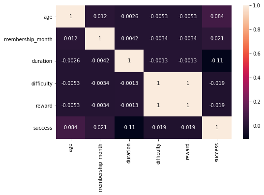

```python
# show the correlation of bogo
plt.figure(figsize = (8, 5))
discount_df = subject_df[subject_df['offer_type'] == 'bogo']
sns.heatmap(discount_df[['age','membership_month','duration','difficulty', 'reward', 'success']].corr(), annot = True)
```

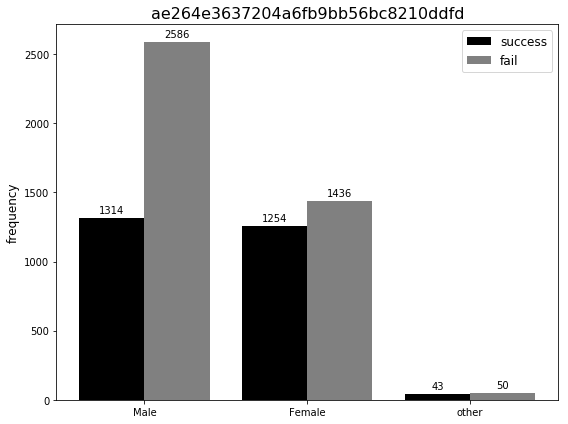

```python
visualize_success(offer_ids[0])
```

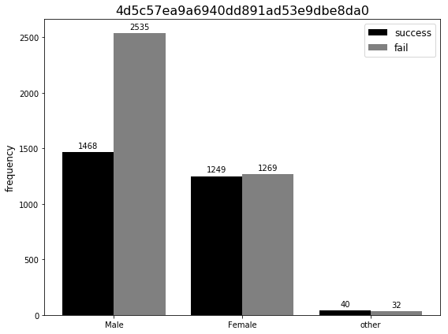

```python
visualize_success(offer_ids[1])
```

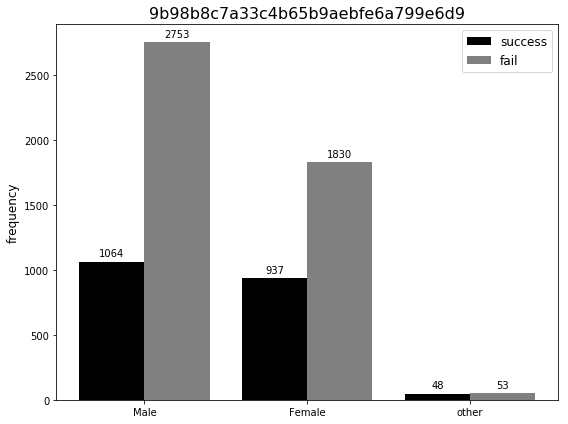

```python
visualize_success(offer_ids[2])
```

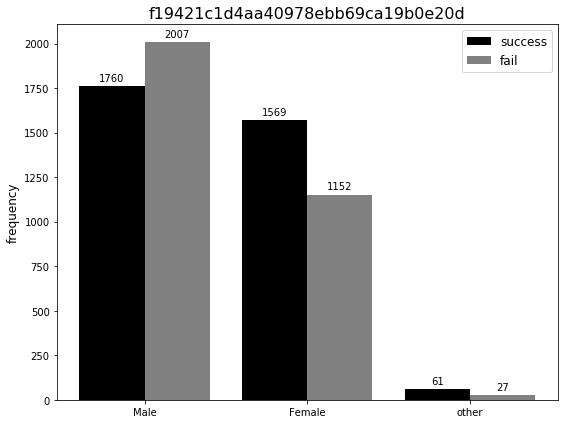

```python
visualize_success(offer_ids[3])
```

```python
def distribution(offer_type, income_or_age):
    """
    Input: offer_type: String , income_or_age: String
    Output:

    this function displays distributions of income or age
    """
    df = subject_df[subject_df['offer_type'] == offer_type]
    success_income = df[df.success == 1][income_or_age]
    fail_income = df[df.success == 0][income_or_age]
    sns.distplot(success_income[success_income.notna()],label='success', color = 'blue')
    sns.distplot(fail_income[fail_income.notna()],label='fail', color = 'red')
    plt.legend()
    plt.show()

    display(df.groupby("gender")[income_or_age].describe())
```

```python
def visualize_success_type(offer_type):

    results = subject_df[subject_df['offer_type'] == offer_type]
    result = results.groupby(["success"])['gender'].value_counts()

    labels = ['Male', 'Female','other']
    success_ = result[1.0]
    fail_ = result[0.0]


    x = np.arange(len(labels))  # the label locations
    width = 0.4  # the width of the bars

    fig, ax = plt.subplots(figsize = (8, 6))
    rects1 = ax.bar(x - width/2, success_ , width, label='success', color = 'black')
    rects2 = ax.bar(x + width/2, fail_, width, label='fail', color = 'gray')

    # Add some text for labels, title and custom x-axis tick labels, etc.
    ax.set_ylabel('frequency', fontsize = 12)
    ax.set_title('results', fontsize = 16)
    ax.set_xticks(x)
    ax.set_xticklabels(labels)
    ax.legend(fontsize = 12)


    def autolabel(rects):
        """Attach a text label above each bar in *rects*, displaying its height."""
        for rect in rects:
            height = rect.get_height()
            ax.annotate('{}'.format(height),
                        xy=(rect.get_x() + rect.get_width() / 2, height),
                        xytext=(0, 3),  # 3 points vertical offset
                        textcoords="offset points",
                        ha='center', va='bottom')

    autolabel(rects1)
    autolabel(rects2)
    fig.tight_layout()

    plt.show()
```

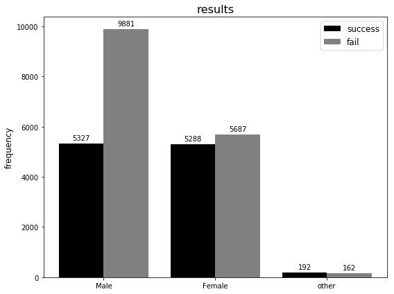

```python
# show the whole results of bogo
visualize_success_type('bogo')
```

## Q: Success-fail distribution by gender.

## A: success rate of female is higher than male’s

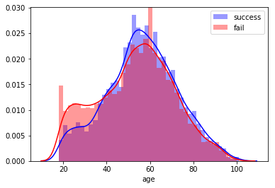

| gender | count | mean | std | min | 25% | 50% | 75% | max |
| --- | --- | --- | --- | --- | --- | --- | --- | --- |
| F | 10975.0 | 57.484920 | 17.001520 | 18.0 | 48.0 | 58.0 | 69.0 | 101.0 |
| M | 15208.0 | 52.038072 | 17.312391 | 18.0 | 40.0 | 53.0 | 64.0 | 100.0 |
| O | 354.0 | 55.172316 | 16.443438 | 20.0 | 43.0 | 55.0 | 67.0 | 100.0 |

```python
distribution('bogo', 'age')
```

```python
# show age represents

def t_test(income_or_age, offer_type = None):
    """
    Input: offer_type: String, income_or_age: String
    output:

    """
    data = subject_df.groupby('gender')[income_or_age].describe().reset_index()

    if offer_type:
        data = subject_df.query(f"offer_type == '{offer_type}'").groupby('gender')[income_or_age].describe().reset_index()
    F = data[data['gender'] == 'F']
    M = data[data['gender'] == 'M']
    O = data[data['gender'] == 'O']
    # def t_test(data)
    # calculate standard errors
    seM, seF = float(M["std"])/np.sqrt(float(M["count"])), float(F["std"])/np.sqrt(float(F["count"]))
    sed = np.sqrt(seM**2.0 + seF**2.0)
    t_stat = (float(M["mean"]) - float(F["mean"])) / sed
    # degrees of freedom
    df = float(M["count"]) + float(F["count"]) - 2
    alpha = 0.05
    # calculate the critical value
    cv = t.ppf(1.0 - alpha, df)
    p = (1.0 - t.cdf(abs(t_stat), df)) * 2.0
    print('t=%.3f, df=%d, cv=%.3f, p=%.3f' % (t_stat, df, cv, p))
    # interpret via critical value
    if abs(t_stat) <= cv:
        print('Accept null hypothesis that the means are equal.')
    else:
        print('Reject the null hypothesis that the means are equal.')
    # interpret via p-value
    if p > alpha:
        print('Accept null hypothesis that the means are equal.')
    else:
        print('Reject the null hypothesis that the means are equal.')
```

```python
from scipy.stats import t
t_test('age', 'bogo')
```

```
t=-25.384, df=26181, cv=1.645, p=0.000
Reject the null hypothesis that the means are equal.
Reject the null hypothesis that the means are equal.
```

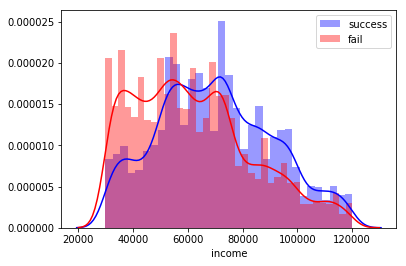

| gender | count | mean | std | min | 25% | 50% | 75% | max |
| --- | --- | --- | --- | --- | --- | --- | --- | --- |
| F | 10975.0 | 71316.173121 | 22478.179037 | 30000.0 | 54000.0 | 71000.0 | 88000.0 | 120000.0 |
| M | 15208.0 | 61218.371910 | 20178.811672 | 30000.0 | 45000.0 | 59000.0 | 73000.0 | 120000.0 |
| O | 354.0 | 63468.926554 | 19065.427693 | 30000.0 | 51000.0 | 63000.0 | 79000.0 | 100000.0 |

```python
distribution('bogo', 'income')
```

```python
t_test('income', 'bogo')
```

```
t=-37.422, df=26181, cv=1.645, p=0.000
Reject the null hypothesis that the means are equal.
Reject the null hypothesis that the means are equal.
```

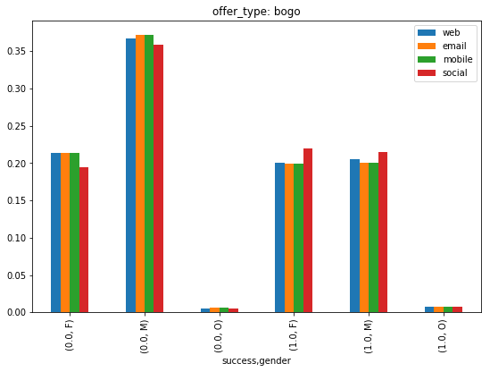

```python
show_channel_dist('bogo')
```

[figure not shown]

```python
# show the whole bogo channel
subject_df[subject_df.offer_type == 'bogo'][["web", "email", "mobile", "social"]].sum().plot(kind = 'bar', title = f'offer_type: {offer_type}, channel counts', figsize = (6,4))
plt.show()
```

```python
## show successful portfolio
offer_type = 'bogo'
subject_df.query(f"success == 1 & offer_type == '{offer_type}'")[['reward','difficulty','duration','viewed_time','completed_time']].describe()
```

|  | reward | difficulty | duration | viewed_time | completed_time |
| --- | --- | --- | --- | --- | --- |
| count | 11108.000000 | 11108.000000 | 11108.000000 | 11108.000000 | 11108.00000 |
| mean | 7.438333 | 7.438333 | 5.860101 | 17.023407 | 53.71372 |
| std | 2.499352 | 2.499352 | 0.990210 | 20.776477 | 38.54541 |
| min | 5.000000 | 5.000000 | 5.000000 | 0.000000 | 0.00000 |
| 25% | 5.000000 | 5.000000 | 5.000000 | 0.000000 | 24.00000 |
| 50% | 5.000000 | 5.000000 | 5.000000 | 12.000000 | 48.00000 |
| 75% | 10.000000 | 10.000000 | 7.000000 | 24.000000 | 78.00000 |
| max | 10.000000 | 10.000000 | 7.000000 | 162.000000 | 168.00000 |

## Q: Average response time

## A: (viewed_time, completed_time): (17.0 hours, 53.7hours)

# discount

## results of discount

```python
discount = portfolio[portfolio.offer_type == 'discount']
offer_ids = discount.offer_id.unique()
discount
```

|  | difficulty | duration | offer_id | offer_type | reward | web | email | mobile | social |
| --- | --- | --- | --- | --- | --- | --- | --- | --- | --- |
| 4 | 20 | 10 | 0b1e1539f2cc45b7b9fa7c272da2e1d7 | discount | 5 | 1 | 1 | 0 | 0 |
| 5 | 7 | 7 | 2298d6c36e964ae4a3e7e9706d1fb8c2 | discount | 3 | 1 | 1 | 1 | 1 |
| 6 | 10 | 10 | fafdcd668e3743c1bb461111dcafc2a4 | discount | 2 | 1 | 1 | 1 | 1 |
| 9 | 10 | 7 | 2906b810c7d4411798c6938adc9daaa5 | discount | 2 | 1 | 1 | 1 | 0 |

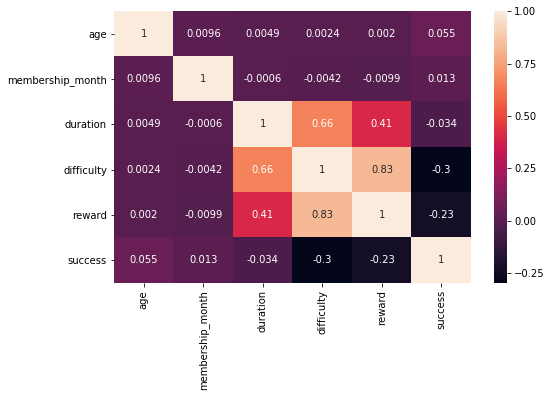

```python
# show the correlation of discount
plt.figure(figsize = (8, 5))
discount_df = subject_df[subject_df['offer_type'] == 'discount']
sns.heatmap(discount_df[['age','membership_month','duration','difficulty', 'reward', 'success']].corr(), annot = True)
```

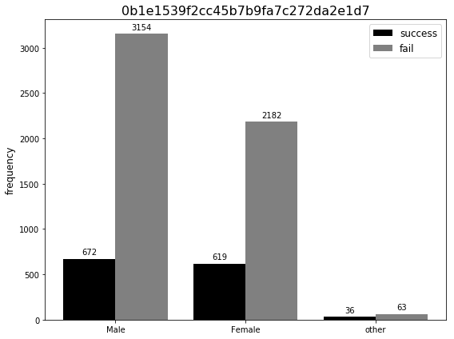

```python
visualize_success(offer_ids[0])
```

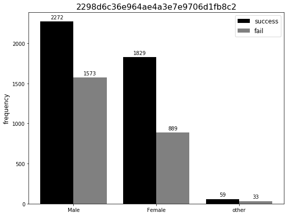

```python
visualize_success(offer_ids[1])
```

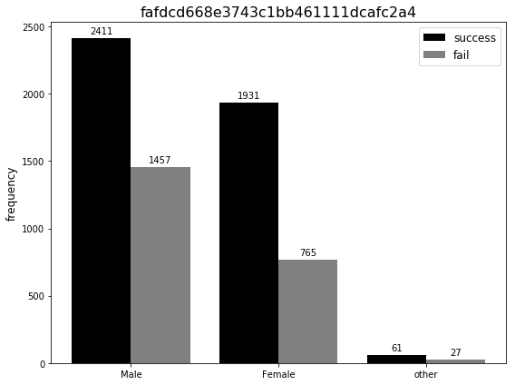

```python
visualize_success(offer_ids[2])
```

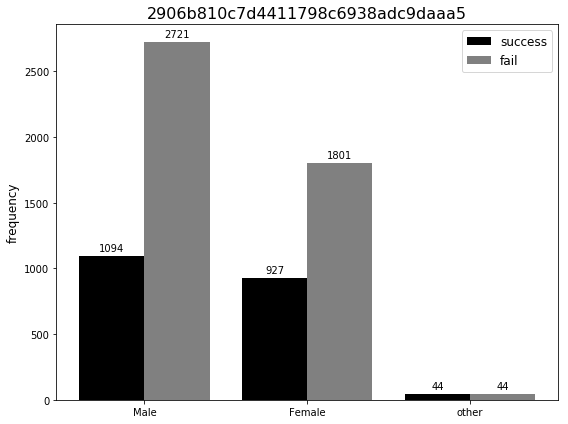

```python
visualize_success(offer_ids[3])
```

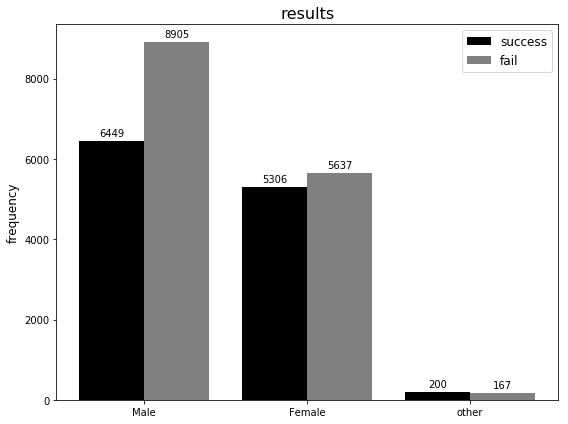

```python
# show the whole results of discount
visualize_success_type('discount')
```

## Q: Success-fail distribution by gender.

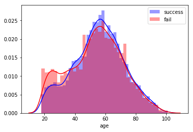

| gender | count | mean | std | min | 25% | 50% | 75% | max |
| --- | --- | --- | --- | --- | --- | --- | --- | --- |
| F | 10943.0 | 57.494197 | 16.770749 | 18.0 | 48.0 | 58.0 | 68.0 | 101.0 |
| M | 15354.0 | 52.050736 | 17.502168 | 18.0 | 39.0 | 53.0 | 65.0 | 100.0 |
| O | 367.0 | 53.937330 | 16.045322 | 20.0 | 42.5 | 55.0 | 66.0 | 92.0 |

```python
# show age distribution of discount
distribution('discount', 'age')
```

```python
t_test('age', 'discount')
```

```
t=-25.477, df=26295, cv=1.645, p=0.000
Reject the null hypothesis that the means are equal.
Reject the null hypothesis that the means are equal.
```

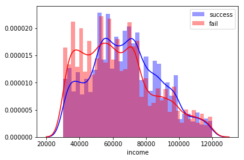

| gender | count | mean | std | min | 25% | 50% | 75% | max |
| --- | --- | --- | --- | --- | --- | --- | --- | --- |
| F | 10943.0 | 71211.276615 | 22299.500722 | 30000.0 | 54000.0 | 71000.0 | 87000.0 | 120000.0 |
| M | 15354.0 | 61185.033216 | 20060.033849 | 30000.0 | 45000.0 | 59000.0 | 73000.0 | 120000.0 |
| O | 367.0 | 62566.757493 | 18836.375868 | 30000.0 | 50000.0 | 63000.0 | 78000.0 | 100000.0 |

```python
# show income distribution of discount
distribution('discount', 'income')
```

```python
t_test('income', 'discount')
```

```
t=-37.457, df=26295, cv=1.645, p=0.000
Reject the null hypothesis that the means are equal.
Reject the null hypothesis that the means are equal.
```

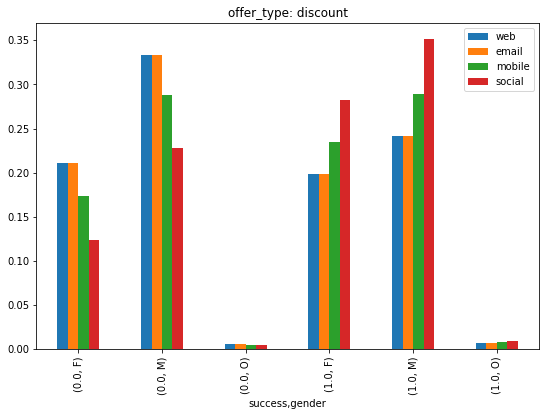

```python
show_channel_dist('discount')
```

[figure not shown]

```python
# show the whole discount channel
subject_df[subject_df.offer_type == 'discount'][["web", "email", "mobile", "social"]].sum().plot(kind = 'bar', title = f'offer_type: {offer_type}, channel counts', figsize = (6,4))
plt.show()
```

```python
## show successful portfolio
offer_type = 'discount'
subject_df.query(f"success == 1 & offer_type == '{offer_type}'")[['reward','difficulty','duration','viewed_time','completed_time']].describe()
```

|  | reward | difficulty | duration | viewed_time | completed_time |
| --- | --- | --- | --- | --- | --- |
| count | 12629.000000 | 12629.000000 | 12629.000000 | 12629.000000 | 12629.000000 |
| mean | 2.670362 | 10.016945 | 8.439069 | 19.891361 | 74.281891 |
| std | 0.928157 | 3.718329 | 1.498821 | 24.728841 | 54.099801 |
| min | 2.000000 | 7.000000 | 7.000000 | 0.000000 | 0.000000 |
| 25% | 2.000000 | 7.000000 | 7.000000 | 0.000000 | 30.000000 |
| 50% | 2.000000 | 10.000000 | 7.000000 | 12.000000 | 66.000000 |
| 75% | 3.000000 | 10.000000 | 10.000000 | 30.000000 | 108.000000 |
| max | 5.000000 | 20.000000 | 10.000000 | 222.000000 | 240.000000 |

It seems the median (rewad, difficulty, duration, viewed_time, completed_time) is (2.0 dollars, 10.0 dollars, 7.0 days, 12.0 hours, 66.0 hours).

## Q: Average response time

```python
clean_df = subject_df.copy()
```

```python
clean_df.drop(['personal_id', 'offer_id','received_time', 'viewed_time', 'completed_time', 'became_member_on','_merge'], axis = 1, inplace = True)
```

```python
clean_df.loc[list(clean_df[clean_df.gender.isna()].index), 'gender'] = clean_df.loc[list(clean_df[clean_df.gender.isna()].index), 'gender'].apply(lambda _: np.random.choice(['F', 'M', 'O'], p=[0.57,  0.41, 0.02]))
```

```python
import scipy.stats as stats
## replace Nan of income
gender = ['M','F','O']
for g in gender:
    mean_ = round(clean_df.query(f"gender == '{g}'").income.mean())
    std_ = round(clean_df.query(f"gender == '{g}'").income.std())
    len_ = len(clean_df[(clean_df['income'].isna()) & (clean_df['gender'] == f'{g}')].index)
    min_ = round(clean_df.query(f"gender == '{g}'").income.min())
    max_ = round(clean_df.query(f"gender == '{g}'").income.max())
    print(g, mean_, std_, len_)
    lower, upper = min_, max_
    mu, sigma = mean_, std_
    choices = stats.truncnorm(
    (lower - mu) / sigma, (upper - mu) / sigma, loc=mu, scale=sigma)
    choices = choices.rvs(len_)
    clean_df.loc[list(clean_df[(clean_df['gender'] == f'{g}') & (clean_df['income'].isna())].index), 'income'] = clean_df.loc[list(clean_df[(clean_df['gender'] == f'{g}') & (clean_df['income'].isna())].index), 'income'].apply(lambda _: np.random.choice(choices))
```

```
M 61200.0 20122.0 4036
F 71237.0 22347.0 5551
O 63163.0 19049.0 190
```

```python
clean_df.groupby("gender").income.describe()
```

| gender | count | mean | std | min | 25% | 50% | 75% | max |
| --- | --- | --- | --- | --- | --- | --- | --- | --- |
| F | 33011.0 | 71338.113458 | 21892.478953 | 30000.0 | 55000.0 | 71000.0 | 87000.0 | 120000.0 |
| M | 42166.0 | 61437.552639 | 19911.690455 | 30000.0 | 46000.0 | 59000.0 | 73000.0 | 120000.0 |
| O | 1106.0 | 63465.816101 | 18554.236030 | 30000.0 | 51000.0 | 63000.0 | 79000.0 | 100000.0 |

```python
import scipy.stats as stats
## replace NaN of age

gender = ['M','F','O']
for g in gender:
    mean_ = round(clean_df.query(f"gender == '{g}'").age.mean())
    std_ = round(clean_df.query(f"gender == '{g}'").age.std())
    len_ = len(clean_df[(clean_df['age'].isna()) & (clean_df['gender'] == f'{g}')].index)
    min_ = round(clean_df.query(f"gender == '{g}'").age.min())
    max_ = round(clean_df.query(f"gender == '{g}'").age.max())
    print(g, mean_, std_, len_)
    lower, upper = min_, max_
    mu, sigma = mean_, std_
    choices = stats.truncnorm(
    (lower - mu) / sigma, (upper - mu) / sigma, loc=mu, scale=sigma)
    choices = choices.rvs(len_)
    clean_df.loc[list(clean_df[(clean_df['gender'] == f'{g}') & (clean_df['age'].isna())].index), 'age'] = clean_df.loc[list(clean_df[(clean_df['gender'] == f'{g}') & (clean_df['age'].isna())].index), 'age'].apply(lambda _: np.random.choice(choices))
```

```
M 52.0 17.0 4036
F 57.0 17.0 5551
O 55.0 16.0 190
```

```python
# drop NaN
clean_df.dropna(inplace = True)
```

```python
# get dummies of gender, and offer_type
dummies = pd.get_dummies(clean_df[['gender', 'offer_type']])
```

```python
# concat dummies and clean_df
cleaned_df = pd.concat([clean_df.drop(['gender', 'offer_type'], axis =1), dummies], axis = 1)
```

## Model

We use RandomForestClassifier

```python
from sklearn.ensemble import RandomForestClassifier
from sklearn.datasets import make_classification
from sklearn.model_selection import train_test_split
from sklearn.metrics import accuracy_score
```

```python
np.random.seed(42)
```

```python
# splid datasets into train, valid, and test
X_train, X_test, y_train, y_test = train_test_split(cleaned_df.drop("success", axis = 1), cleaned_df['success'], test_size=0.2, random_state=42)
X_train, X_valid, y_train, y_valid = train_test_split(X_train, y_train, test_size=0.2, random_state=42)
```

```python
clf = RandomForestClassifier(max_depth=10, min_samples_leaf = 5, min_samples_split = 5)
```

```python
clf.fit(X_train,  y_train)
```

```
RandomForestClassifier(bootstrap=True, class_weight=None, criterion='gini',
            max_depth=10, max_features='auto', max_leaf_nodes=None,
            min_impurity_decrease=0.0, min_impurity_split=None,
            min_samples_leaf=5, min_samples_split=5,
            min_weight_fraction_leaf=0.0, n_estimators=10, n_jobs=1,
            oob_score=False, random_state=None, verbose=0,
            warm_start=False)
```

```python
# accuracy of valid datasets
accuracy_score(clf.predict(X_valid), y_valid)
```

```
0.76067185579680463
```

```python
# accuracy of test datasets
accuracy_score(clf.predict(X_test), y_test)
```

```
0.75458835867855267
```

Hence, the model accuracy is 0.755

## Report

- female members are more likely to complete offers than males.
- female members are older than male and have higher income.
- in the bogo offer, web and social channels more contributes to success; in the discount offer, mobile and social chennels more impacts on success.